# Predicting legendary Pokemon with a machine learning model

```r
poke_data %>% filter(is.na(height_m)) %>% tally(is_legendary > 0)
```

```
## # A tibble: 1 x 1
##       n
##   <int>
## 1     1
```

```r
poke_data %>% filter(is.na(percentage_male)) %>% tally(is_legendary > 0)
```

```
## # A tibble: 1 x 1
##       n
##   <int>
## 1    63
```

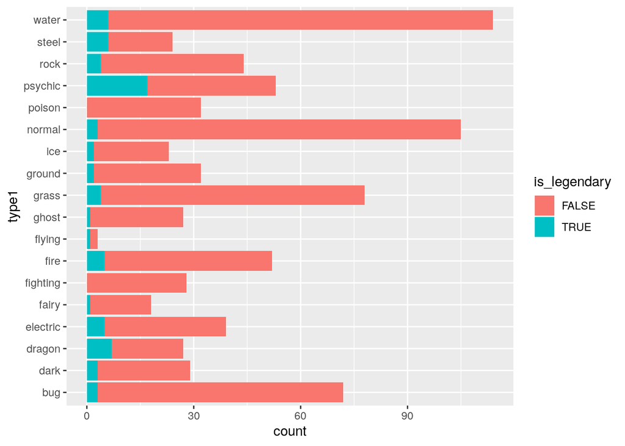

```r
# Let's remove the problematic "percentage_male" column. See text below for explanation.
poke_data <- poke_data %>%
  select(-percentage_male)

# Plot the relationship of non-legendary vs legendary Pokemon among the variables.
ggplot(poke_data, aes(x=type1)) +
  geom_bar(aes(fill=is_legendary, group=is_legendary)) +
  coord_flip()
```

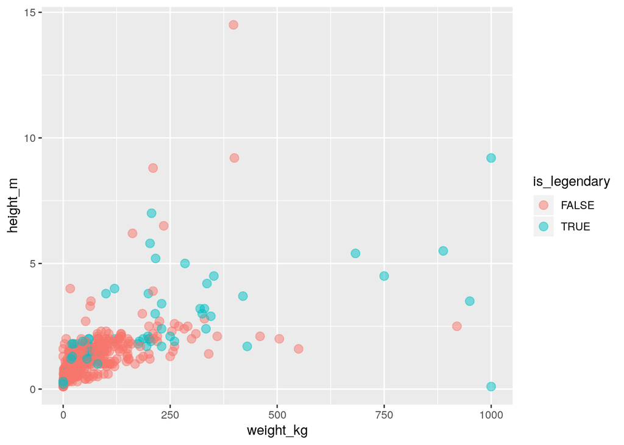

```r
ggplot(poke_data, aes(x=weight_kg, y=height_m, color=is_legendary)) +
  geom_point(size=3, alpha=0.5)
```

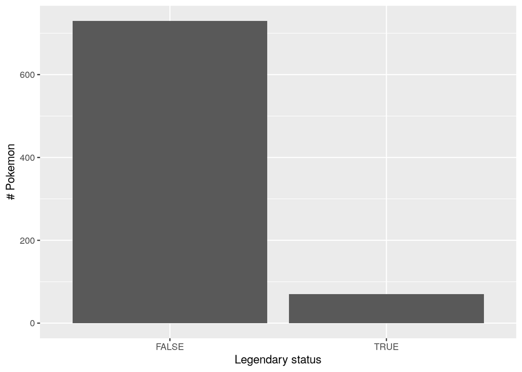

```r
# Plot the distrbution of the target (or response) variable and see if there is any class imbalance.
ggplot(poke_data, aes(x=is_legendary)) +
  geom_bar() +
  xlab("Legendary status") +
  ylab("# Pokemon")
```

Missing values in the “percentage_male” column is particularly problematic, since there are a lot of legendary Pokemon in this subset. The reason for this is that legendary Pokemon are commonly genderless.

We can’t replace N/A with “none” like we did with the types above, because then we would be mixing numeric and character values. We can’t replace N/A with 0, because then that would imply 100% female, which is false. We can’t impute it, because it will predict a value between 0 and 100, which is also incorrect.

## Splitting the dataset for training and testing

We need to split the dataset into training data (75%) and test data (25%). When building the predictive model, the algorithm should see the training data and **ONLY** the training data to learn the relationship between Pokemon stats and their legendary status. Learned information about these relationships become our machine learning model.

```r
# Now let's divide the dataset into training and test sets. The caret package has a nice function, createDataPartition(), for this purpose.

set.seed(13)

partition_index <- createDataPartition(poke_data$is_legendary, p=0.75, list=FALSE)

trainPoke <- poke_data[partition_index,]

testPoke <- poke_data[-partition_index,]
```

## Dealing with missing data

There is no one-size-fits-all method for dealing with missing data. I found a nice overview for the different ways you can deal with missing values in predictive analytics in a data science blog (https://towardsdatascience.com/how-to-handle-missing-data-8646b18db0d4):

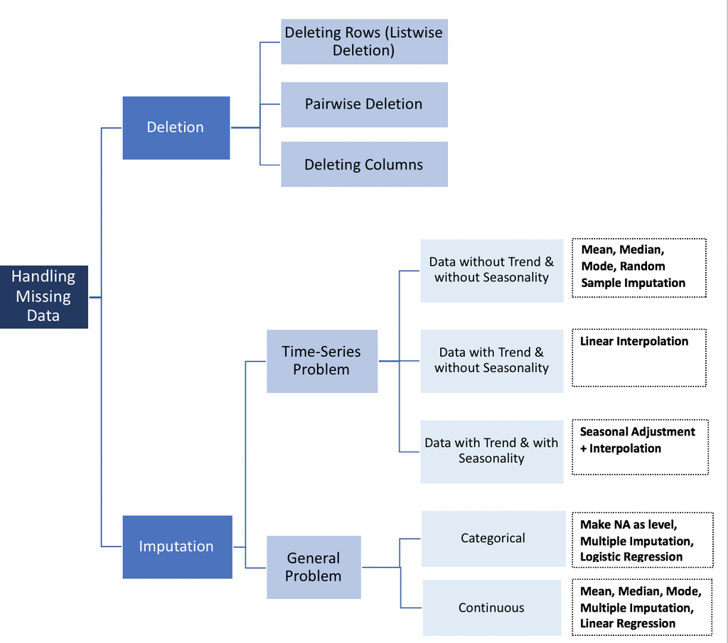

Ways to deal with missing data

The missing values in the “weight_kg” and “height_m” columns are less complex to deal with. These missing values represent a smaller portion of the dataset, and result from a bug in the web scraping script used to generate the csv.

Let’s take this as an opportunity to demonstrate what imputation, or value prediction, might look like. We can impute the missing values by considering the rest of the available variables as predictors using the k-Nearest Neighbors algorithm. Luckily caret has a built-in function for this, preProcess().

Before we do that, we need to partition our data into training and test sets. We want our test set to be **completely independent** of our training set, and that includes participation in imputation.

```r
# The "name" column is not important to model training, so let's take it out to avoid having to encode the labels.
trainPoke <- trainPoke %>%
  select(-name) %>%
  mutate(is_legendary = as.factor(is_legendary))

# Now let's make a model for predicting the missing values in the weight and height columns.
poke_missingdata_model <- preProcess(trainPoke, method='knnImpute')

poke_missingdata_model
```

```
## Created from 586 samples and 36 variables
##
## Pre-processing:
##   - centered (33)
##   - ignored (3)
##   - 5 nearest neighbor imputation (33)
##   - scaled (33)
```

```r
# The output shows that the model has centered (substracted by mean) 33 variables, ignored 3 variables, used k=5 (considered 5 nearest neighbors) to predict missing values and finally scaled (divide by standard deviation) 33 variables.

# Now let's use this model to predict the missing values.
trainPoke_pp <- predict(poke_missingdata_model, newdata = trainPoke)

# Check to see if any N/A values remain. If FALSE, all values have been successfully imputed.
anyNA(trainPoke_pp)
```

```
## [1] FALSE
```

```r
# We can also revisit the skim() function to confirm no missing values are present.
skim(trainPoke_pp)
```

Data summary

| Name | trainPoke_pp |
| --- | --- |
| Number of rows | 601 |
| Number of columns | 36 |
| _______________________ |  |
| Column type frequency: |  |
| character | 2 |
| factor | 1 |
| numeric | 33 |
| ________________________ |  |
| Group variables | None |

**Variable type: character**

| skim_variable | n_missing | complete_rate | min | max | empty | n_unique | whitespace |
| --- | --- | --- | --- | --- | --- | --- | --- |
| type1 | 0 | 1 | 3 | 8 | 0 | 18 | 0 |
| type2 | 0 | 1 | 3 | 8 | 0 | 19 | 0 |

**Variable type: factor**

| skim_variable | n_missing | complete_rate | ordered | n_unique | top_counts |
| --- | --- | --- | --- | --- | --- |
| is_legendary | 0 | 1 | FALSE | 2 | FAL: 548, TRU: 53 |

**Variable type: numeric**

| skim_variable | n_missing | complete_rate | mean | sd | p0 | p25 | p50 | p75 | p100 | hist |
| --- | --- | --- | --- | --- | --- | --- | --- | --- | --- | --- |
| against_bug | 0 | 1 | 0 | 1.00 | -1.24 | -0.83 | -0.01 | -0.01 | 4.91 | ▇▁▂▁▁ |
| against_dark | 0 | 1 | 0 | 1.00 | -1.83 | -0.14 | -0.14 | -0.14 | 6.60 | ▇▁▁▁▁ |
| against_dragon | 0 | 1 | 0 | 1.00 | -2.80 | 0.08 | 0.08 | 0.08 | 2.96 | ▁▁▇▁▁ |
| against_electric | 0 | 1 | 0 | 1.00 | -1.63 | -0.87 | -0.10 | -0.10 | 4.48 | ▅▇▃▁▁ |
| against_fairy | 0 | 1 | 0 | 1.00 | -1.56 | -0.13 | -0.13 | -0.13 | 5.59 | ▇▁▁▁▁ |
| against_fight | 0 | 1 | 0 | 1.00 | -1.48 | -0.78 | -0.09 | -0.09 | 4.07 | ▇▇▅▁▁ |
| against_fire | 0 | 1 | 0 | 1.00 | -1.27 | -0.91 | -0.20 | 1.21 | 4.05 | ▆▇▅▁▁ |
| against_flying | 0 | 1 | 0 | 1.00 | -1.53 | -0.33 | -0.33 | 1.26 | 4.43 | ▇▁▂▁▁ |
| against_ghost | 0 | 1 | 0 | 1.00 | -1.75 | 0.02 | 0.02 | 0.02 | 5.33 | ▂▇▂▁▁ |
| against_grass | 0 | 1 | 0 | 1.00 | -0.98 | -0.67 | -0.05 | -0.05 | 3.70 | ▇▁▂▁▁ |
| against_ground | 0 | 1 | 0 | 1.00 | -1.47 | -0.80 | -0.13 | -0.13 | 3.90 | ▅▇▃▁▁ |
| against_ice | 0 | 1 | 0 | 1.00 | -1.33 | -0.98 | -0.28 | 1.11 | 3.91 | ▇▁▃▁▁ |
| against_normal | 0 | 1 | 0 | 1.00 | -3.21 | 0.43 | 0.43 | 0.43 | 0.43 | ▁▁▁▁▇ |
| against_poison | 0 | 1 | 0 | 1.00 | -1.80 | -0.87 | 0.05 | 0.05 | 5.62 | ▃▇▂▁▁ |
| against_psychic | 0 | 1 | 0 | 1.00 | -2.07 | 0.00 | 0.00 | 0.00 | 6.18 | ▂▇▂▁▁ |
| against_rock | 0 | 1 | 0 | 1.00 | -1.42 | -0.36 | -0.36 | 1.06 | 3.90 | ▇▁▃▁▁ |
| against_steel | 0 | 1 | 0 | 1.00 | -1.50 | -0.98 | 0.05 | 0.05 | 6.26 | ▅▇▂▁▁ |
| against_water | 0 | 1 | 0 | 1.00 | -1.32 | -0.91 | -0.09 | -0.09 | 4.85 | ▅▇▂▁▁ |
| attack | 0 | 1 | 0 | 1.00 | -2.24 | -0.73 | -0.11 | 0.69 | 3.31 | ▂▇▆▂▁ |
| base_egg_steps | 0 | 1 | 0 | 1.00 | -0.89 | -0.32 | -0.32 | -0.32 | 3.49 | ▇▁▁▁▁ |
| base_happiness | 0 | 1 | 0 | 1.00 | -3.23 | 0.25 | 0.25 | 0.25 | 3.72 | ▁▁▇▁▁ |
| base_total | 0 | 1 | 0 | 1.00 | -2.03 | -0.88 | 0.02 | 0.64 | 2.89 | ▃▆▇▂▁ |
| capture_rate | 0 | 1 | 0 | 1.00 | -1.30 | -0.75 | -0.35 | 1.03 | 2.02 | ▇▅▂▃▂ |
| defense | 0 | 1 | 0 | 1.00 | -2.17 | -0.73 | -0.15 | 0.56 | 5.04 | ▅▇▂▁▁ |
| experience_growth | 0 | 1 | 0 | 1.00 | -2.77 | -0.35 | -0.35 | 0.01 | 3.53 | ▂▇▅▅▁ |
| height_m | 0 | 1 | 0 | 0.99 | -0.96 | -0.51 | -0.16 | 0.28 | 11.82 | ▇▁▁▁▁ |
| hp | 0 | 1 | 0 | 1.00 | -2.69 | -0.75 | -0.15 | 0.44 | 7.18 | ▃▇▁▁▁ |
| pokedex_number | 0 | 1 | 0 | 1.00 | -1.69 | -0.84 | 0.00 | 0.87 | 1.76 | ▇▇▇▇▇ |
| sp_attack | 0 | 1 | 0 | 1.00 | -1.87 | -0.80 | -0.19 | 0.58 | 3.75 | ▅▇▅▁▁ |
| sp_defense | 0 | 1 | 0 | 1.00 | -1.80 | -0.75 | -0.18 | 0.66 | 5.58 | ▇▇▂▁▁ |
| speed | 0 | 1 | 0 | 1.00 | -2.08 | -0.70 | -0.15 | 0.67 | 3.94 | ▅▇▆▁▁ |
| weight_kg | 0 | 1 | 0 | 0.99 | -0.58 | -0.49 | -0.31 | 0.04 | 9.04 | ▇▁▁▁▁ |
| generation | 0 | 1 | 0 | 1.00 | -1.37 | -0.85 | 0.19 | 0.71 | 1.76 | ▇▅▃▅▅ |

## Categorical variables in machine learning

Categorical data are variables that contain character values rather than numeric values. For instance, Pokemon types are categories like “fairy” and “fire.” Many machine learning algorithms don’t operate on category data directly, requiring all input and output variable to be numeric.

However, the tree-based algorithms we’re going to use handle it just fine, so we’re not going to bother with it here.

## Training the model

There are many, many different machine learning algorithms (for both classification and regression) available via the caret package. For today’s demo, we will be training a Random Forest model because it plays nice with categorical data and datasets with imbalanced classes.

With any machine learning model, we need some kind of assurance that the model has extracted most of the patterns from the data correctly. We need to make sure that its not picking up too much noise, i.e., the model has low bias and variance. This process is known as **validation**. To figure out how well our classifier will generalize to an independent/unseen dataset, we’ll use **k-fold cross validation**. This method divides the training data in k subsets. Then, one of the k substs is used as the test set and the other k-1 subsets are put together to form a training set. This is repeated k times.

Since every data point gets to be in a validation set exactly once, and gets to be in a training set k-1 times, this signficantly reduces the bias (as we use most of the data for fitting) and variance (as most of the data is also being used in validation).

```r
# designate validation method
fitControl <- trainControl(method="repeatedcv", number=5,
                           repeats=5)


# fit a "Random Forest" model; ~206.871 seconds
pokeFit_ranf <- train(is_legendary~., data=trainPoke_pp, method = "rf",
                    trControl=fitControl)

pokeFit_ranf
```

```
## Random Forest
##
## 601 samples
##  35 predictor
##   2 classes: 'FALSE', 'TRUE'
##
## No pre-processing
## Resampling: Cross-Validated (5 fold, repeated 5 times)
## Summary of sample sizes: 481, 481, 480, 481, 481, 481, ...
## Resampling results across tuning parameters:
##
##   mtry  Accuracy   Kappa
##    2    0.9820438  0.8729632
##   35    0.9953443  0.9708658
##   68    0.9953415  0.9710380
##
## Accuracy was used to select the optimal model using the largest value.
## The final value used for the model was mtry = 35.
```

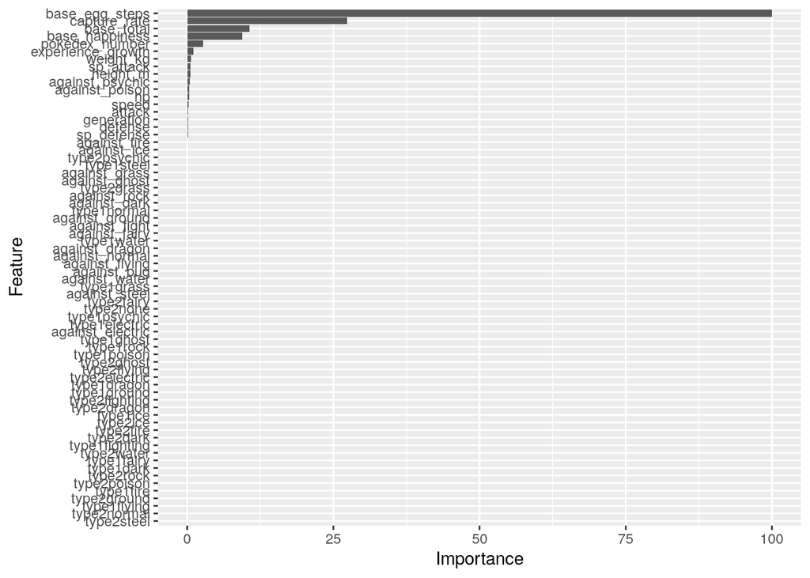

```r
varimp_ranf <- varImp(pokeFit_ranf)
ggplot(varimp_ranf)
```

```r
testPoke_pp <- predict(poke_missingdata_model, testPoke) %>%
  mutate(is_legendary=as.factor(is_legendary))

anyNA(testPoke_pp)
```

```
## [1] FALSE
```

```r
predictionPoke <- predict(pokeFit_ranf, testPoke_pp)
predictionPoke
```

```
##   [1] FALSE FALSE FALSE FALSE FALSE FALSE FALSE FALSE FALSE FALSE FALSE
##  [12] FALSE FALSE FALSE FALSE FALSE FALSE FALSE FALSE FALSE FALSE FALSE
##  [23] FALSE FALSE FALSE FALSE FALSE FALSE FALSE FALSE FALSE FALSE TRUE
##  [34] FALSE FALSE FALSE FALSE FALSE FALSE FALSE FALSE FALSE FALSE FALSE
##  [45] FALSE FALSE FALSE FALSE FALSE FALSE FALSE FALSE FALSE FALSE FALSE
##  [56] FALSE FALSE FALSE TRUE  FALSE FALSE FALSE FALSE FALSE FALSE FALSE
##  [67] FALSE FALSE FALSE FALSE FALSE FALSE FALSE FALSE FALSE FALSE FALSE
##  [78] FALSE FALSE FALSE FALSE FALSE FALSE FALSE FALSE FALSE FALSE FALSE
##  [89] FALSE TRUE  FALSE FALSE FALSE FALSE FALSE FALSE FALSE FALSE FALSE
## [100] FALSE FALSE FALSE FALSE FALSE FALSE FALSE TRUE  TRUE  FALSE TRUE
## [111] FALSE TRUE  FALSE FALSE FALSE FALSE FALSE FALSE FALSE FALSE FALSE
## [122] FALSE FALSE FALSE FALSE FALSE FALSE FALSE FALSE FALSE FALSE FALSE
## [133] FALSE FALSE FALSE FALSE FALSE FALSE FALSE FALSE FALSE FALSE FALSE
## [144] FALSE FALSE FALSE FALSE FALSE FALSE FALSE FALSE FALSE FALSE FALSE
## [155] FALSE TRUE  TRUE  TRUE  FALSE FALSE FALSE FALSE FALSE FALSE FALSE
## [166] FALSE FALSE FALSE FALSE FALSE FALSE FALSE FALSE FALSE TRUE  FALSE
## [177] FALSE FALSE FALSE FALSE FALSE FALSE FALSE FALSE FALSE FALSE FALSE
## [188] FALSE FALSE FALSE TRUE  TRUE  FALSE FALSE TRUE  TRUE  TRUE  TRUE
## [199] TRUE
## Levels: FALSE TRUE
```

```r
testPoke_pp$predicted <- predict(pokeFit_ranf, testPoke_pp)

target_outcomes <- testPoke_pp %>%
  select(name, is_legendary, predicted) %>%
  arrange(desc(is_legendary), desc(predicted))

confusionMatrix(reference=testPoke_pp$is_legendary, data=predictionPoke, mode='everything', positive='TRUE')
```

```
## Confusion Matrix and Statistics
##
##           Reference
## Prediction FALSE TRUE
##      FALSE   180    1
##      TRUE      2   16
##
##                Accuracy : 0.9849
##                  95% CI : (0.9566, 0.9969)
##     No Information Rate : 0.9146
##     P-Value [Acc > NIR] : 2.387e-05
##
##                   Kappa : 0.906
##
##  Mcnemar's Test P-Value : 1
##
##             Sensitivity : 0.94118
##             Specificity : 0.98901
##          Pos Pred Value : 0.88889
##          Neg Pred Value : 0.99448
##               Precision : 0.88889
##                  Recall : 0.94118
##                      F1 : 0.91429
##              Prevalence : 0.08543
##          Detection Rate : 0.08040
##    Detection Prevalence : 0.09045
##       Balanced Accuracy : 0.96509
##
##        'Positive' Class : TRUE
##
```

## Evaluating your model

A confusion matrix is a table that is often used to describe the performance of a classifier on a set of test data for which the true values are known. This is the basic structure:

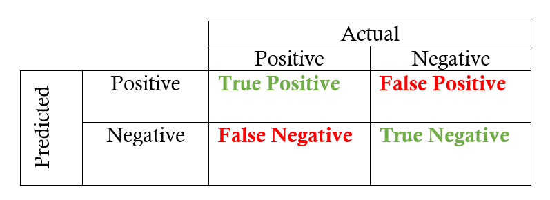

Confusion matrices are used to calculate precision and recall, like so:

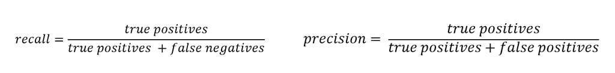

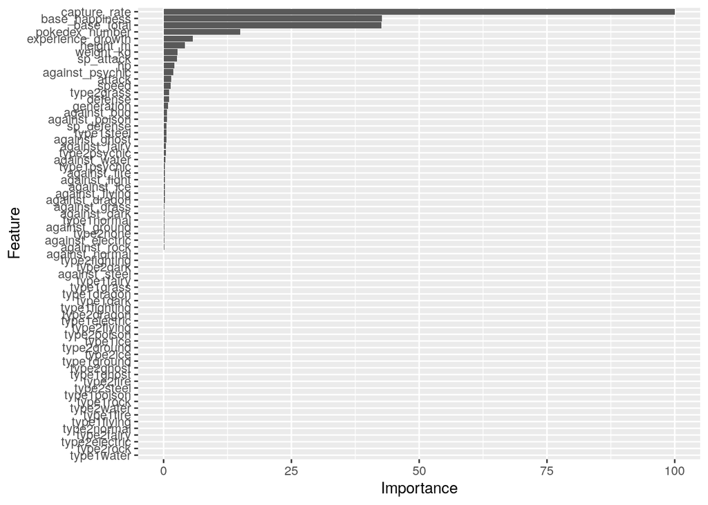

```r
### remove feature
poke_data_noegg <- poke_data %>%
  select(-base_egg_steps)

### split data
set.seed(13)

partition_index_noegg <- createDataPartition(poke_data_noegg$is_legendary, p=0.75, list=FALSE)

trainPoke_noegg <- poke_data_noegg[partition_index,]

testPoke_noegg <- poke_data_noegg[-partition_index,]

### train model
trainPoke_noegg <- trainPoke_noegg %>%
  select(-name) %>%
  mutate(is_legendary = as.factor(is_legendary))

poke_missingdata_model_noegg <- preProcess(trainPoke_noegg, method='knnImpute')

trainPoke_pp_noegg <- predict(poke_missingdata_model_noegg, newdata = trainPoke_noegg)

pokeFit_ranf_noegg <- train(is_legendary~., data=trainPoke_pp_noegg, method = "rf",
                    trControl=fitControl)

varimp_ranf_noegg <- varImp(pokeFit_ranf_noegg)
ggplot(varimp_ranf_noegg)
```

```r
### test model
testPoke_pp_noegg <- predict(poke_missingdata_model_noegg, testPoke_noegg) %>%
  mutate(is_legendary=as.factor(is_legendary))

anyNA(testPoke_pp_noegg)
```

```
## [1] FALSE
```

```r
predictionPoke_noegg <- predict(pokeFit_ranf_noegg, testPoke_pp_noegg)

testPoke_pp_noegg$predicted <- predict(pokeFit_ranf_noegg, testPoke_pp_noegg)

target_outcomes_noegg <- testPoke_pp_noegg %>%
  select(name, is_legendary, predicted) %>%
  arrange(desc(is_legendary), desc(predicted))

### evaluate model
confusionMatrix(reference=testPoke_pp_noegg$is_legendary, data=predictionPoke_noegg, mode='everything', positive='TRUE')
```

```
## Confusion Matrix and Statistics
##
##           Reference
## Prediction FALSE TRUE
##      FALSE   180    1
##      TRUE      2   16
##
##                Accuracy : 0.9849
##                  95% CI : (0.9566, 0.9969)
##     No Information Rate : 0.9146
##     P-Value [Acc > NIR] : 2.387e-05
##
##                   Kappa : 0.906
##
##  Mcnemar's Test P-Value : 1
##
##             Sensitivity : 0.94118
##             Specificity : 0.98901
##          Pos Pred Value : 0.88889
##          Neg Pred Value : 0.99448
##               Precision : 0.88889
##                  Recall : 0.94118
##                      F1 : 0.91429
##              Prevalence : 0.08543
##          Detection Rate : 0.08040
##    Detection Prevalence : 0.09045
##       Balanced Accuracy : 0.96509
##
##        'Positive' Class : TRUE
##
```

## Testing other models

```r
modelLookup() %>% filter(forReg==FALSE)
```

[output not shown]

## Other things to consider that we are not covering here…

Regression models  
Encoding categorical variables  
Feature engineering  
Tuning your model

# Thanks for coming to my demo!

[figure not shown]

Bye!

# Scratch notes

```r
# Convert categorical variables to as many binary variables as there are categories
dummyPoke_model <- dummyVars(is_legendary~., data=trainPoke)

# Create dummy variables using predict
trainPoke_encoded <- predict(dummyPoke_model, newdata=trainPoke)
```